# Inauguration Speech Analysis

Carlos Blancarte

January 25, 2017

```r
# Libraries
library(tidyverse)
library(magrittr)
library(stringr)
library(stringi)
library(tidytext)
library(ggthemes)
library(scales)
library(knitr)
```

## Read in the data

```r
data <- read_csv("/users/carlosblancarte/Documents/code/inauguration_speeches/data/speech_data_clean.csv")
```

## Analysis

I’m primarily interested in detecting and comparing sentiment between presidential inauguration speeches. It’s likely that these speeches tend to be uplifting and more positive than most, but I believe there may be notable differences between presidents. Especially given the contentious 2000 and 2016 elections.

I’d also like to visualize the sentiment throughout the narrative *time* of the speech. Do speeches begin with very low sentiment and build up at the end?

## Data Prep

Part of the reason for going through with this project was because I wanted to play around with the `tidytext` package. The package contains many useful functions for data wranglin’ text that align with *tidy* principles. We’ll begin by restructuring the data using `unnest_tokens` to tokenize sentences first, and single words afterward.

```r
# double unnest_tokens!
dataLong <- unnest_tokens(
    tbl=data,
    output=sentence,
    input=content,
    to_lower=TRUE,
    token='sentences'
    ) %>%
  group_by(speech_date, president) %>%
  mutate(sentence_index = row_number(),
         total_sentences = max(sentence_index)) %>%
  ungroup() %>%
  unnest_tokens(
    tbl=.,
    output=word,
    input=sentence,
    token='words',
    drop=FALSE
  ) %>%
  ungroup() %>%
  select(speech_date, president, sentence, sentence_index, total_sentences, word)
```

### removing stop words

If we want to remove stopword we can utilize the dataset `stop_words` and `anti_join` it to our dataset. This will ensure that pesky filler words like *too*, *then*, *the*, etc.

```r
# load data
data('stop_words')
```

## descriptive stats

Now we can take a look at a few high-level stats about the speeches as a whole:

| speech_date | president | total_sentences | total_words | Average Words Per Sentence |
| --- | --- | --- | --- | --- |
| 2001-01-20 | George W. Bush | 84 | 621 | 11.026846 |
| 2005-01-20 | George W. Bush | 98 | 840 | 11.045838 |
| 2009-01-20 | Barack Obama | 110 | 893 | 12.446808 |
| 2013-01-21 | Barack Obama | 89 | 842 | 12.399027 |
| 2017-01-20 | Donald J. Trump | 61 | 376 | 7.426829 |

Which words are used most frequently?

```r
# count top10 highest frequency words
dataClean %>%
  count(speech_date, president, word, total_words) %>%
  ungroup() %>%
  arrange(speech_date, president, desc(n)) %>%
  group_by(speech_date, president) %>%
  mutate(percent_of_total_words = percent(n/total_words)) %>%
  slice(1:3) %>%
  kable()
```

[output not shown]

No real surprise here… the president is addressing the nation in these inauguration speeches so it’s no surprise that words like `america`, `freedom`, and `liberty` all make it to the top of the list. It’s also worth noting that relatively low frequency with which these words are used - hovering around 1 to 3 percent.

# Sentiment

Performing any kind of *sentiment* analysis can be tricky since we’re essentially dealing with a bag of words and assigning each word a score without taking context or negation into account. Thusly, it’s important to review the output to ensure that the scoring is consistent with what you would expect. We know that the results won’t be perfect, but at least we can still gain some sort of insight.

## BING sentiment

We’ll begin by using the `bing` lexicon to score our words. This lexicon scores words as either being negative or positive. The implementation in the `tidytext` package currently contains over 6,000 words!

Using an `inner_join` we’ll restrict our data to only include words found in the lexicon and then count the number of positive and negative words for each sentence in each speech. Given that these are official transcripts i’m not too concerned about misspelled words getting cut out of the analysis from using an inner join.

```r
# create bing scored data
  dataBing <- dataClean %>%
  inner_join(get_sentiments('bing'), by='word') %>%
  count(president, speech_date, sentence_index, sentiment) %>%
  spread(sentiment, n, fill=0) %>%
  mutate(sentiment = positive - negative) %>%
  ungroup() %>%
  # fills in implicit missing values with 0
  complete(sentence_index, nesting(speech_date, president),
    fill=list(negative=0, positive=0, sentiment=0)) %>%
  arrange(speech_date, sentence_index) %>%
  left_join(., totalSentences, by = 'speech_date') %>%
  group_by(speech_date) %>%
  filter(sentence_index <= total_sentences) %>%
  ungroup()
```

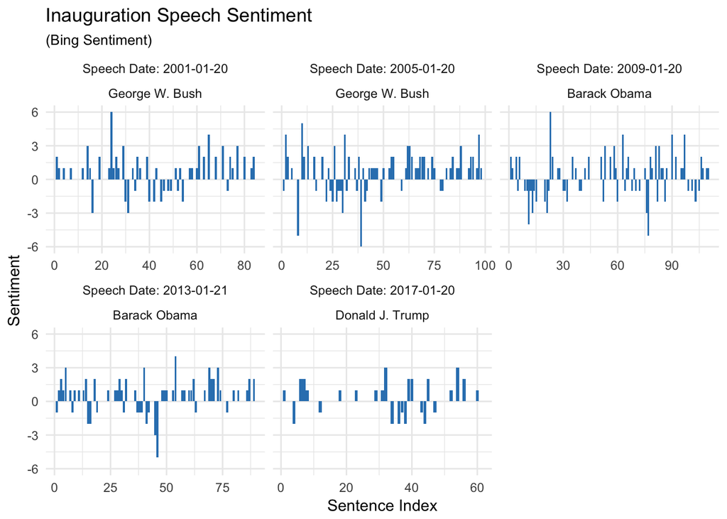

The first thing that jumps out me is how less varied Trump’s speech is. Not only is it shorter than all the other speeches (which we’ve already mentioned) but it doesn’t pack the same punch in terms of sentiment. It seems to be much more neutral when compared to the rest of the speeches. Positive sentiment tops out at 3 while negative sentiment tops out at 2.

| speech_date | president | sentiment_minimum | sentiment_maximum |
| --- | --- | --- | --- |
| 2001-01-20 | George W. Bush | -3 | 6 |
| 2005-01-20 | George W. Bush | -6 | 5 |
| 2009-01-20 | Barack Obama | -5 | 6 |
| 2013-01-21 | Barack Obama | -5 | 4 |
| 2017-01-20 | Donald J. Trump | -2 | 3 |

Let’s take a look at some of the sentences with the min/max sentiment scores for each president:

### Most positive sentences

| speech_date | president | sentiment | sentence |
| --- | --- | --- | --- |
| 2001-01-20 | George W. Bush | 6 | today, we affirm a new commitment to live out our nation’s promise through civility, courage, compassion and character. |
| 2001-01-20 | George W. Bush | 4 | i will live and lead by these principles, “to advance my convictions with civility, to pursue the public interest with courage, to speak for greater justice and compassion, to call for responsibility … |
| 2001-01-20 | George W. Bush | 3 | our democratic faith is more than the creed of our country, it is the inborn hope of our humanity, an ideal we carry but do not own, a trust we bear and pass along; and even after nearly 225 years, we… |
| 2005-01-20 | George W. Bush | 5 | we are led, by events and common sense, to one conclusion: the survival of liberty in our land increasingly depends on the success of liberty in other lands. |
| 2005-01-20 | George W. Bush | 4 | chief justice, president carter, president bush, president clinton, members of the united states congress, reverend clergy, distinguished guests, fellow citizens:on this day, prescribed by law and mar… |
| 2005-01-20 | George W. Bush | 4 | we will encourage reform in other governments by making clear that success in our relations will require the decent treatment of their own people. |
| 2009-01-20 | Barack Obama | 6 | the time has come to reaffirm our enduring spirit; to choose our better history; to carry forward that precious gift, that noble idea, passed on from generation to generation: the god-given promise th… |
| 2009-01-20 | Barack Obama | 4 | and so to all other peoples and governments who are watching today, from the grandest capitals to the small village where my father was born: know that america is a friend of each nation and every man… |
| 2009-01-20 | Barack Obama | 4 | but those values upon which our success depends - hard work and honesty, courage and fair play, tolerance and curiosity, loyalty and patriotism - these things are old. |
| 2013-01-21 | Barack Obama | 4 | our brave men and women in uniform, tempered by the flames of battle, are unmatched in skill and courage. |
| 2013-01-21 | Barack Obama | 3 | what makes us exceptional – what makes us american – is our allegiance to an idea articulated in a declaration made more than two centuries ago: we hold these truths to be self-evident, that all men a… |
| 2013-01-21 | Barack Obama | 3 | we do not believe that in this country freedom is reserved for the lucky, or happiness for the few. |
| 2017-01-20 | Donald J. Trump | 3 | these are just and reasonable demands of righteous people and a righteous public. |
| 2017-01-20 | Donald J. Trump | 3 | protection will lead to great prosperity and strength. |
| 2017-01-20 | Donald J. Trump | 2 | every four years we gather on these steps to carry out the orderly and peaceful transfer of power. |

I tend to agree that most of these sentences are genearlly positive in their message. There’s nothing that immediately stands out to as looking *off* or like it doesn’t belong.

We can also focus on the sentences that scored the highest on negative sentiment:

### Most negative sentences

| speech_date | president | sentiment | sentence |
| --- | --- | --- | --- |
| 2001-01-20 | George W. Bush | -3 | the ambitions of some americans are limited by failing schools and hidden prejudice and the circumstances of their birth; and sometimes our differences run so deep, it seems we share a continent, but … |
| 2001-01-20 | George W. Bush | -3 | if we permit our economy to drift and decline, the vulnerable will suffer most. |
| 2001-01-20 | George W. Bush | -2 | if we do not turn the hearts of children toward knowledge and character, we will lose their gifts and undermine their idealism. |
| 2005-01-20 | George W. Bush | -6 | today, america speaks anew to the peoples of the world:all who live in tyranny and hopelessness can know: the united states will not ignore your oppression, or excuse your oppressors. |
| 2005-01-20 | George W. Bush | -5 | for as long as whole regions of the world simmer in resentment and tyrannyprone to ideologies that feed hatred and excuse murderviolence will gather, and multiply in destructive power, and cross the m… |
| 2005-01-20 | George W. Bush | -3 | america will not pretend that jailed dissidents prefer their chains, or that women welcome humiliation and servitude, or that any human being aspires to live at the mercy of bullies. |
| 2009-01-20 | Barack Obama | -5 | to those who cling to power through corruption and deceit and the silencing of dissent, know that you are on the wrong side of history; but that we will extend a hand if you are willing to unclench yo… |
| 2009-01-20 | Barack Obama | -4 | our economy is badly weakened, a consequence of greed and irresponsibility on the part of some, but also our collective failure to make hard choices and prepare the nation for a new age. |
| 2009-01-20 | Barack Obama | -3 | our healthcare is too costly; our schools fail too many; and each day brings further evidence that the ways we use energy strengthen our adversaries and threaten our planet. |
| 2013-01-21 | Barack Obama | -5 | some may still deny the overwhelming judgment of science, but none can avoid the devastating impact of raging fires and crippling drought and more powerful storms. |
| 2013-01-21 | Barack Obama | -3 | we will respond to the threat of climate change, knowing that the failure to do so would betray our children and future generations. |
| 2013-01-21 | Barack Obama | -2 | together, we resolved that a great nation must care for the vulnerable, and protect its people from lifes worst hazards and misfortune. |
| 2017-01-20 | Donald J. Trump | -2 | we will confront hardships. |
| 2017-01-20 | Donald J. Trump | -2 | mothers and children trapped in poverty in our inner cities, rusted out factories scattered like tombstones across the landscape of our nation. |
| 2017-01-20 | Donald J. Trump | -2 | and the crime and the gangs and the drugs that have stolen too many lives and robbed our country of so much unrealized potential. |

these also look pretty good - comments about oppression, poverty, and hardships all make an appearance. Overall, I feel pretty good about the results.

turning our attention back to the graph: There isn’t a discernable pattern prevalent in all of the speeches. Sure, most addresses tend to begin positively and build up a bit before turning negative (mostly in the form of bringing up social and international issues) before ending on a generally positive note. Again, the Trump speech stands out for it’s neutrality. I assume that a lot of thought goes into writing a presidental address and the choice of wording is very deliberate. Perhaps his address was designed so it wouldn’t be soo contentious? Or perhaps it just so happens that the vocabulary used was less likely to be included in the `bing` lexicon?

Let’s try normalzing the sentiment by number of words in each sentence. This will give us a fairer comparison between presidents, assuring that the scale is between negative 1 and positive 1. In essence, we’re computing the average sentement per word.

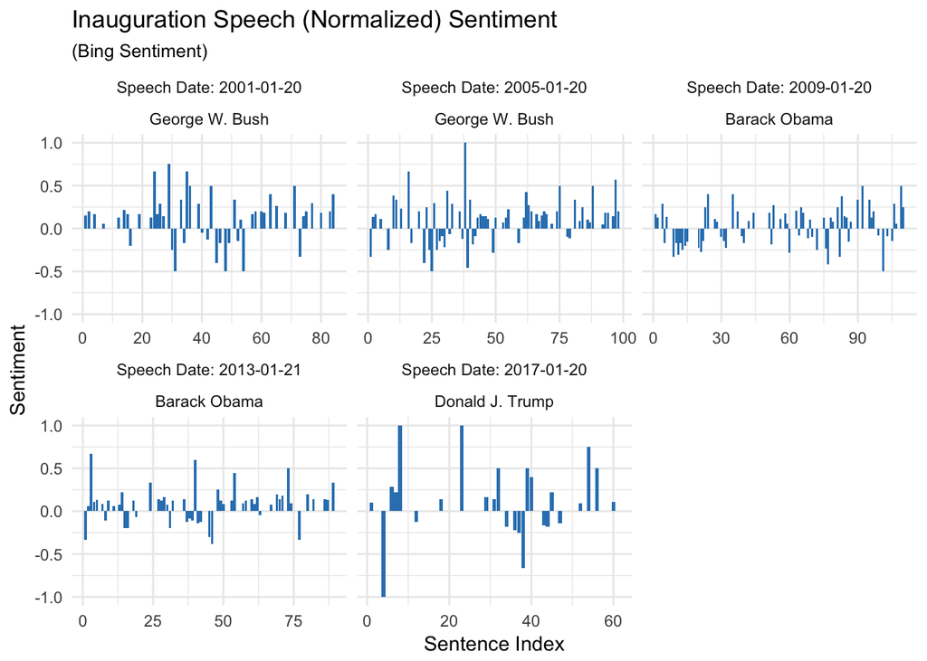

I need to do a little more research, but using `nrc` for sentiment scoring provides additional emotional measurements such as anger, anticipation, disgust, fear, joy, etc.

```r
# nrcScored <- dataLong %>%
#   anti_join(., stop_words, by='word') %>%
#   inner_join(get_sentiments('nrc'), by='word') %>%
#   count(president, speech_date, sentence_index, sentiment) %>%
#   spread(sentiment, n, fill=0) %>%
#   mutate(sentiment = positive - negative) %>%
#   #gather(emotion, score, anger:joy, sadness:trust) %>%
#   ungroup() %>%
#   complete(sentence_index, nesting(speech_date, president),
#            fill=list(anger=0,
#                      anticipation=0,
#                      disgust=0,
#                      fear=0,
#                      joy=0,
#                      negative=0,
#                      positive=0,
#                      sadness=0,
#                      surprise=0,
#                      trust=0,
#                      sentiment=0)) %>%
#   arrange(speech_date, sentence_index)
#
# # plot Trumps speech
# nrcScored %>%
#   filter(grepl('trump', tolower(president))) %>%
#   gather(sentiment, score, anger:sentiment) %>%
#   ggplot(., aes(x=sentence_index, y=score)) +
#   geom_bar(stat='identity') +
#   facet_wrap(~sentiment)
#
# # plot 'trust'
# nrcScored %>%
#   filter(emotion %in% 'trust') %>%
#   ggplot(., aes(x=sentence_n, y=score)) +
#   geom_bar(stat='identity') +
#   facet_wrap(speech_date ~ president)
```